# Eksploracja danych geoprzestrzennych

Projekt

Author

Dominik Jagosz

# Przygotowanie.

## Ładowanie bibliotek.

```r
library("dplyr")
library("terra")
library("tidyr")
library("ggplot2")
library("caret")
library("rpart")
library("rpart.plot")
library("kableExtra")
library("tidyterra")
library("patchwork")
library("scales")
library("corrplot")
library("bestNormalize")
library("mclust")
library("cluster")
library("gstat")
library("sf")
library("tmap")
library("RColorBrewer")
library("gridExtra")
```

## Ustawienie ziarna losowości.

```r
set.seed(10)
```

## Wczytanie danych.

Dostępne jest 520 punktów.

## Przyporzadkowanie wartości z rastrów do punktów.

# Eksploracja danych.

## Mapy, wykresy pudełkowe, histogramy z gęstością.

Wszystkie kanały mają taki sam zasięg i układ współrzędnych, kanały rastrowe mają jednakową rozdzielczość. Wartości brakujące występują tylko w miejscach zbiorników wodnych.

### Zmienne niezależne.

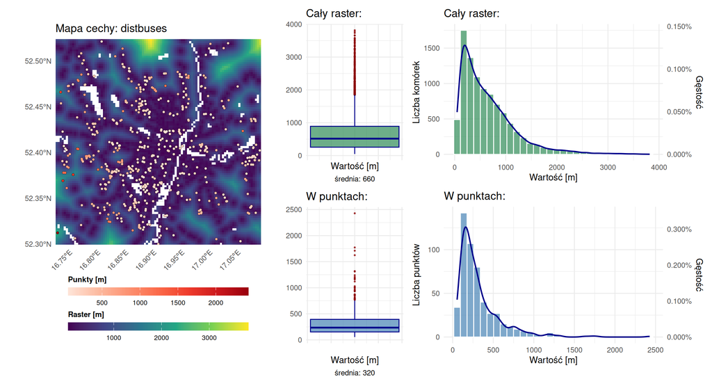

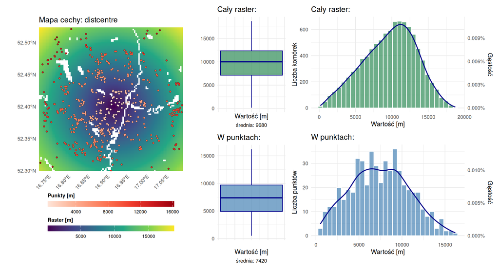

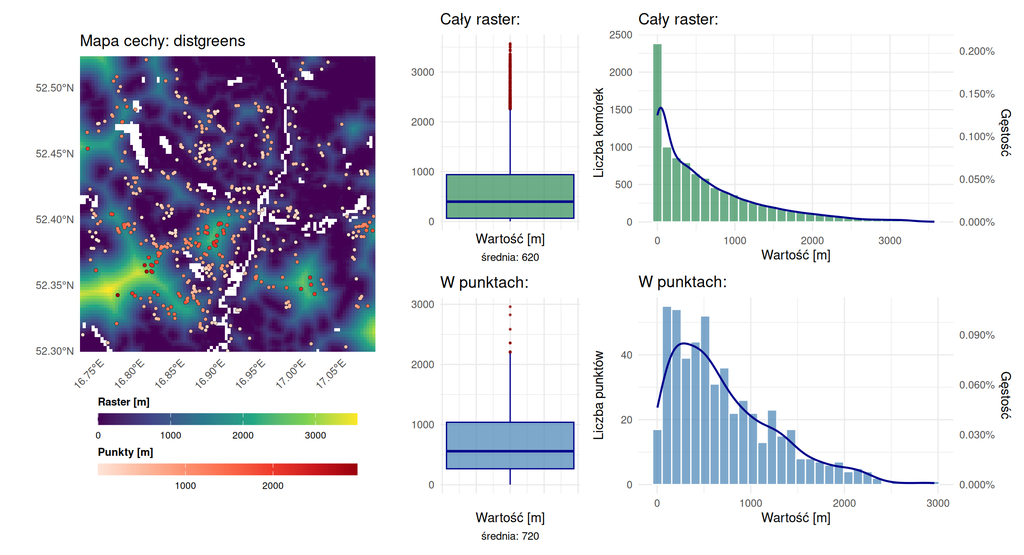

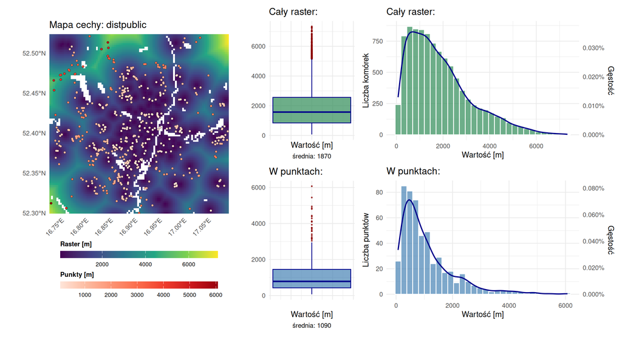

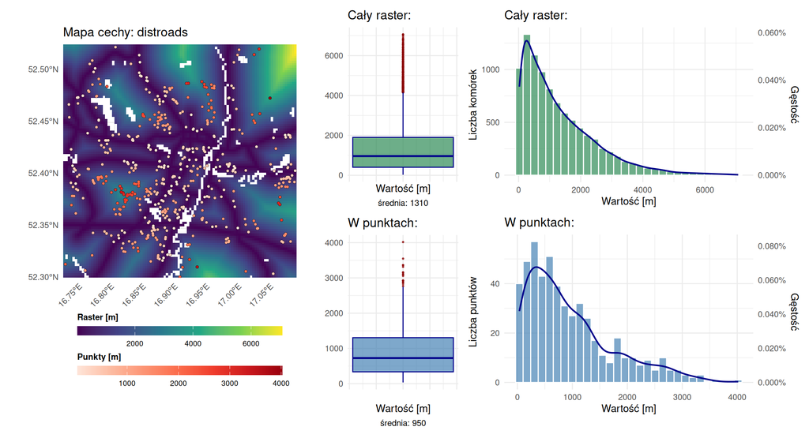

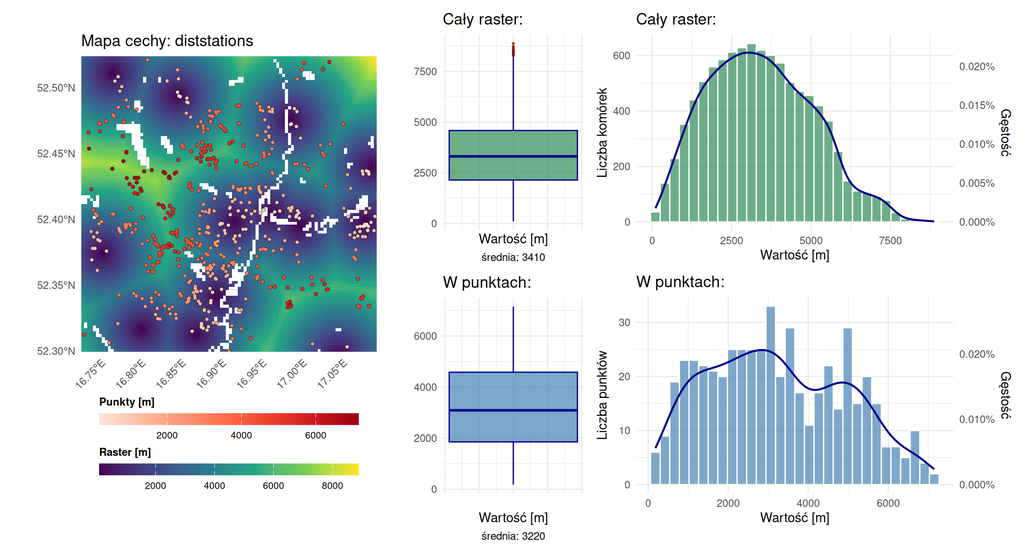

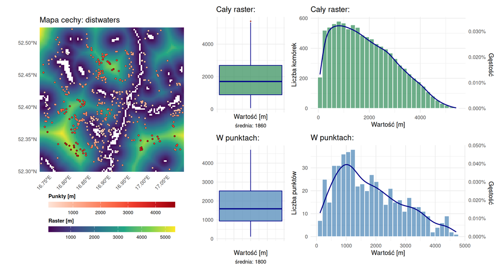

### Zmienna zależna.

#### Wszystkie punkty.

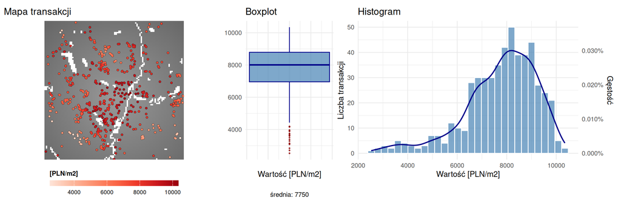

#### Punkty z ceną za metr między 5 a 10 tys.

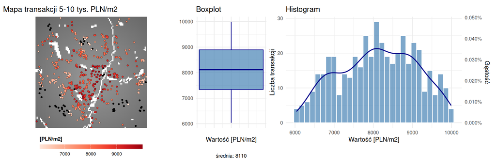

## Usunięcie wartości odstających.

### Analiza.

Analizuję głównie wartości cech w punktach, sugeruję się wykresami pudełkowymi i histogramami dla nich. Tworzę zbiór z usuniętymi wartościami odstającymi oraz zbiór z dodatkową winsoryzacją do porównania.

Zmienne niezależne:

- **disitbuses** - Najwyższa dopuszczalna opcja ustawienia “max. pieszo z/do przystanku” przy wyszukiwaniu polączeń w aplikacji mobileMPK to 900m. Wartości większe 1,5 raza od 900m usuwam. Wartościom pomiędzy 900 a 1350m przypisuję 900m w przypadku winsoryzacji.
- **distcentre** - Zostawiam bez zmian - liczności spadają równomiernie w obu kierunkach od mediany wartości, bo odległość od centrum zwiększa się promieniście od punktu położonego blisko centrum mapy, czyli liczności rosną od 0m do momentu kiedy są ograniczane przez kwadratowy obrys rastra, wtedy to zaczynają spadać i zatrzymują się na maksymalnym zasięgu mapy (ok. 17km). Ewentualnie można by wykluczyć wartości powyżej ok. 12km - to już nie Poznań, a większość punktów o takich wartościach jest w Swarzędzu.
- **distgreen** - Miejsca które mają wartości powyżej wąsa wykresu pudełkowego $(Q3 + 1,5 \cdot IQR)$ (ok. 2100m) to głownie tereny gdzie nie ma parków, ale są pola uprawne - które są nieco podobne do terenów zielonych w przypadku analizy cen nieruchomości, bo można tam spacerować. Wartości większe 1,5 raza (ok. 3000m) usuwam. Wartościom pomiędzy 2100 a 3000m przypisuję 2100m w przypadku winsoryzacji.
- **distpublic** - Powyżej wąsa (ok. 3km) różnice w odległości od urzędów oceniam jako nieznaczące dla mieszkańców. Wartości większe 1,5 raza (ok. 4,5km) usuwam. Wartościom pomiędzy 3km a 4,5km przypisuję 3km w przypadku winsoryzacji.
- **distroads** - Powyżej wąsa (ok. 2,6km) występują duże wartości które mogą być błędem niedoszacowania ważności/przejezdności/uciążliwości drogi w lokalnych warunkach (ul. Poznańska przechodząca przez Kliny). W odległości większej niż 2,6km główna droga powinna już nie być słyszalna i różnicę w czasie dotarcia do niej oceniam jako mało znaczące dla mieszkańców. Najwyższe wartości są w terenach z polami/lasami (Kliny, Mielno) i nie ma tam mieszkań.
- **diststations** - Zostawiam bez zmian, rozkład jest dość zbliżony do normalnego, wystarczy transformacja.
- **distwaters** - Zostawiam bez zmian, rozkład jest dość zbliżony do normalnego, wystarczy transformacja. Uwzględnione są zbiorniki wodne sensownej wielkości, więc odległość jest miarodajna do oceny w jakim stopniu odległość od zbiorników wodnych wpływa na ceny.

Nie chcę usuwać żadnych punktów ze względu na odstającą cenę - punktów jest mało, a nawet najmniejsze ceny nie są niewyobrażalnie niskie (nie są wynikiem błędu). Z drugiej strony ceny nie mają (nawet w zakresie 5-10 tys. PLN/m2) rozkładu normalnego, ani ogona z prawej strony, czego bym się spodziewał po rozkładzie cen nieruchomości, ale mają ogon z lewej strony. To może znaczyć że nie ma informacji o lokalach luksusowych, a są dotyczące ruder albo sprzedaży po znajomości. Dużo punktów o niskich cenach jest np. w Komornikach, może to wynikać po prostu z cech obszaru. Przez to, że w zbiorze nie ma wartości poniżej 2 ani powyżej 11 tys. PLN/m2 mam wrażenie, że intencją autora zbioru było przyjrzenie się pewnemu wycinkowi rynku. Dlatego nie usuwam żadnych punktów.

### Usuwanie.

Zgodnie z wynikiem analizy dla cech punktów usuwam wartości odstające z całych rastrów (`niezalezne.bez.odst`). Dla porównania tworzę zbiór (`niezalezne.winsor`) z dodatkową winsoryzacją zgodnie z analizą (zastąpieniem pozostałych wartości odstających wartością wąsa wykresu pudełkowego dla punktów $(Q3 + 1,5 \cdot IQR)$).

### Przyporzadkowanie wartości z rastrów ze zmienionymi wartościami odstającymi do punktów.

Żeby nie tracić punktów z cenami, jeżeli po ekstrakcji wartości z rastrów z usuniętymi wartościami odstającymi w punktach są cechy z brakującymi wartościami, zastępuje je wartością graniczną, powyżej której wartości odstające były usuwane (np. 1.5*900m dla `distbuses`). Robię to tylko w punktach, a nie rastrach których używam do PCA.

#### Funkcja pomocnicza.

#### Sprawdzenie.

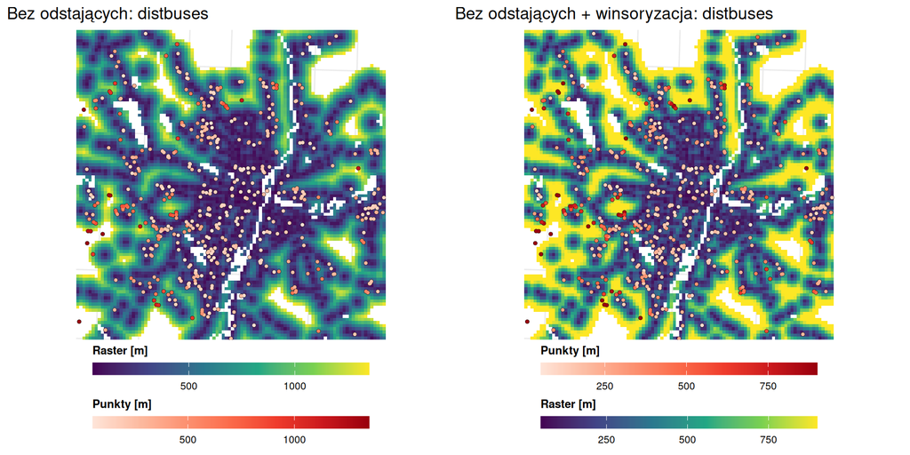

### Pozostawienie tylko komórek z wartościami wszystkich cech w rastrach.

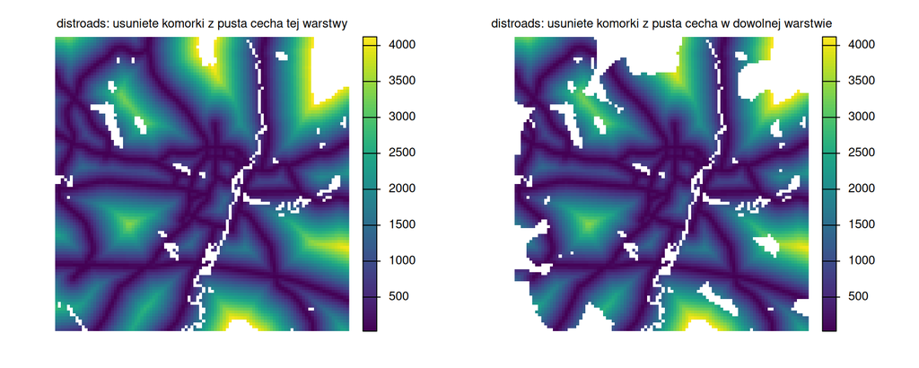

## Macierze korelacji.

### Rastry.

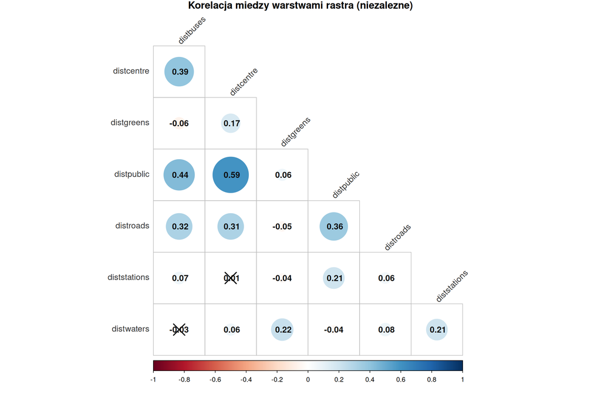

Korelacje public-buses i public-centre sa mocne, ale nie na tyle, żeby usunąć jedną zmienną z pary. Podobnie roads-buses i roads-public.

### Punkty.

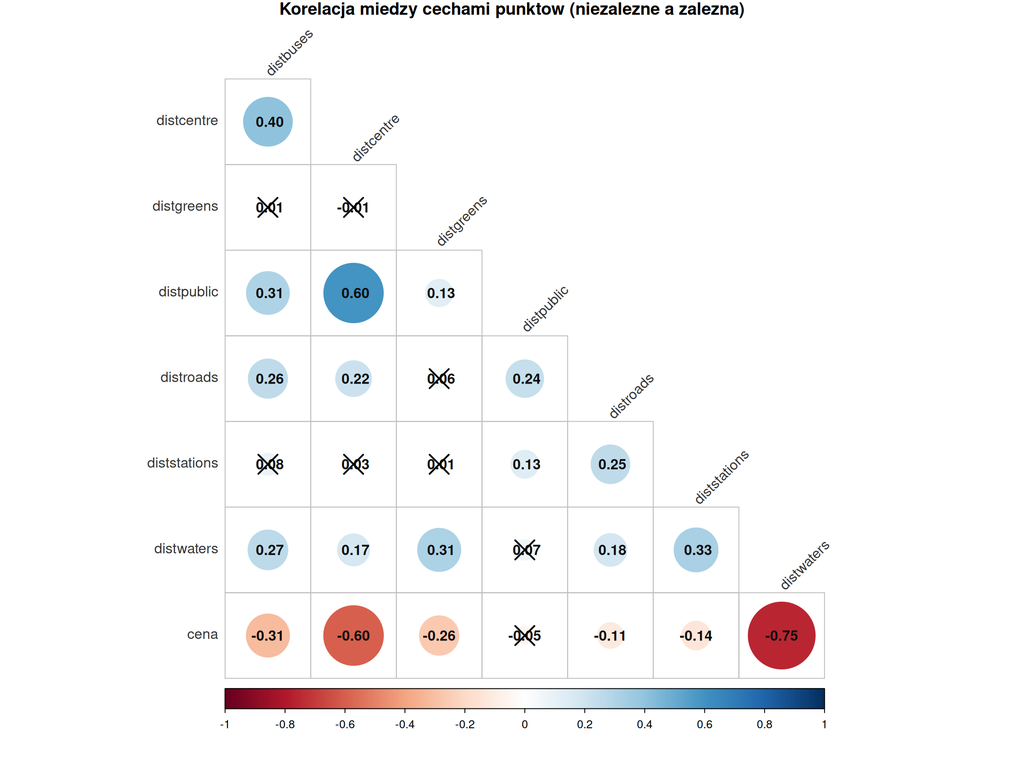

W punktach waertości korelacji nieco się różnią, ale public-centre pozostaje wysokie. Cena jest mocno skorelowana z waters i centre, a wcale z public, pomijalnie z roads, stations. Skoro odległość od administracji publicznej nie jest skorelowana z ceną, a skorelowana z innymi zmiennymi niezależnymi, dla redukcji wymiarowości nie biorę zmiennej (`distpublic`) do obliczeń PCA. Podobnie możnaby wykluczyć `distroads`, ale rozkład przestrzenny odległości od głównych dróg jest na tyle wyrazisty i odróżniający się od pozostałych (linie zamiast kół), że pozostawiam zmienną `distroads`.

# PCA

## Przygotowanie.

Zbiór danych jest niewielki, dlatego PCA wykonuję nie na próbie, tylko na całym zbiorze bez wartości odstających. Predykcję wykonam jedynie dla komórek, w których przynajmniej jedna z cech ma wartość odstającą.

### Funkcja pomocnicza.

### Gęstość przed transformacją.

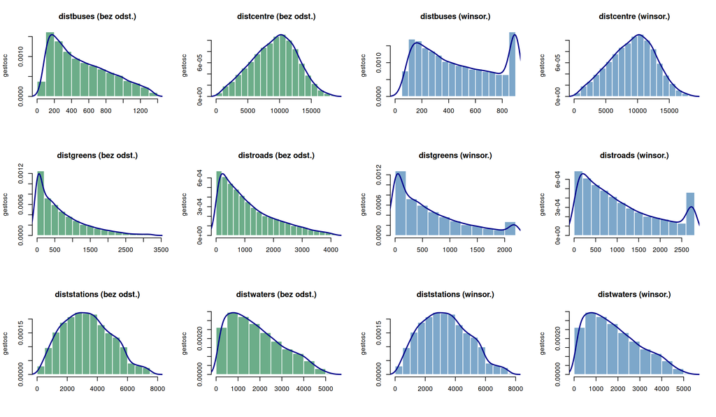

Rozkłady `distcentre` i `diststations` wydają się zbliżone do normalnego, pozostałe są wykazują skośność z ogonem wysokich wartości.

### Transformacja.

Przetestowano transformacje `log_x`, `yeojohnson`, `bestNormalize(allow_orderNorm = FALSE)` dla `niezalezne.df.bez.odst` oraz `bestNormalize(allow_orderNorm = FALSE)` dla `niezalezne.df.winsor`.

Matoda `bestNormalize` wybierała zwykle transformacje `boxcox`, `yeojohnson` albo `sqrt_x`.

### Gęstość po transformacji.

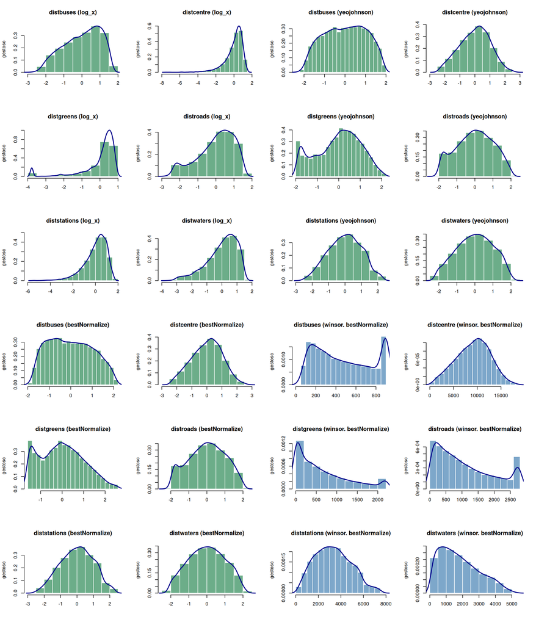

Transformacja `log_x` nie jest wystarczająca. Wszystkie dane są nieujemne, dlatego `yeojohnson` i inne transformacje `bestNormalize` dają niemal jednakowe wyniki. Winsoryzacja znacząco utrudniła transformację do rozkładu normalnego. Najmniej do rozkładu normalnego upodabniają się `distgreens` i `distbuses` - są raczej skośne lub dwumodalne, w zależności od winsoryzacji.

Do dalszych analiz wybieram transformowane `bestNormalize` dane bez danych odstających, bez winsoryzacji. Modele transformacji zapisuję. {#odno1}

### Standaryzacja - skalowanie.

### Transformacja i skalowanie ceny.

Cenę transformuję używając `bestNormalize(allow_orderNorm = FALSE)` i skaluję.

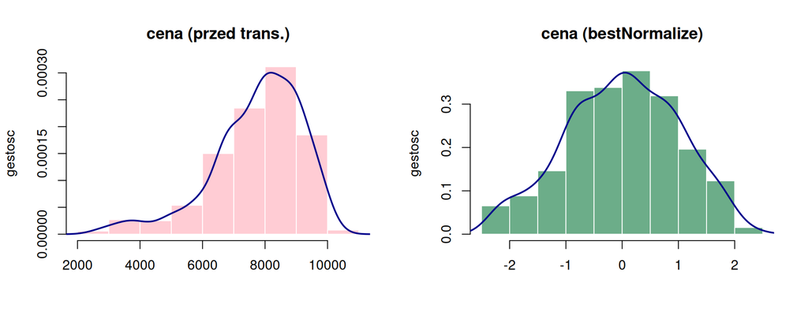

## Analiza głównych składowych.

### Obliczenia.

### Wykres piargowy.

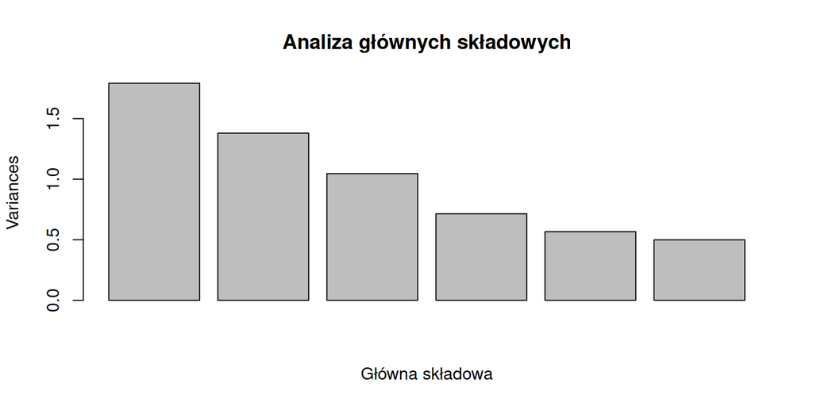

```
Importance of components:
                          PC1    PC2    PC3    PC4     PC5     PC6
Standard deviation     1.3389 1.1749 1.0230 0.8452 0.75272 0.70661
Proportion of Variance 0.2988 0.2301 0.1744 0.1191 0.09443 0.08322
Cumulative Proportion  0.2988 0.5289 0.7033 0.8224 0.91678 1.00000
```

Pierwsze trzy składowe tłumaczą razem około 70% wariancji, różnice między nimi nie są bardzo duże (30-23-18%). Czwarta składowa odpowiada za prawie 12% wariancji.

### Macierz ładunków.

```
                    PC1        PC2         PC3
distbuses    -0.5308201 -0.3059790 -0.07428502
distcentre   -0.5291352 -0.1626766 -0.38057105
distgreens   -0.1633175  0.6580241 -0.38064827
distroads    -0.4625943 -0.2759083  0.21717794
diststations -0.2167183  0.2301261  0.80783079
distwaters   -0.3880889  0.5637677  0.07069273
```

Pierwsza składowa reaguje głównie na odległość od przystanków autobusowych, centrum, głównych dróg, nieco mniej wód.

Druga składowa reaguje głównie na odległość od terenów zielonych, nieco mniej na wód.

Trzecia składowa w przeważającej większości reaguje na odległość od stacji kolejowych

### Biplot.

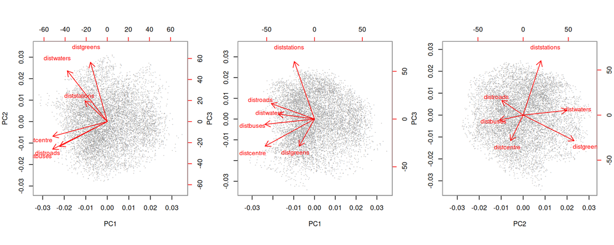

Składowe nie są bardzo wysokiej jakości - punkty są dość rozproszone w chmurach, nie układają się w wyraźne wzory, szególnie przy użyciu trzeciej składowej. Przy porównaniu pierwszej i drugiej składowej zmienne opisujące odległość od terenów zielonych i zbiorników wodnych są skorelowane ze sobą, a niezależne od odległości od centrum i przystanków autobusowych (wektory tworzą kąt zbliżony do prostego). Nie ma żadnych silnie negatywnie skorelowanych zmiennych (kąt 180 stopni). Końce wektorów znajdują się daleko od siebie, przy punktach mocno różniących się od siebie.

## Predykcja dla pozostałych danych.

Wyznaczenie wartości trzech pierwszych składowych dla komórek usuniętych w punkcie Pozostawienie tylko komórek z wartościami wszystkich cech w rastrach.

### Wartości odstające.

Wcześniej wartości odstające uznałem za mało istotne dla zmienności cen i usunąłem z danych, na których wykonałem PCA. Jednak teraz, wykonuję predykcję PCA dla komórek z nimi, nie usuwam ich ani nie zastępuje maksymalną wartością.

### Transformacja i skalowanie.

Transformacje używające zapisanych wcześniej modeli i parametrów skalowania.

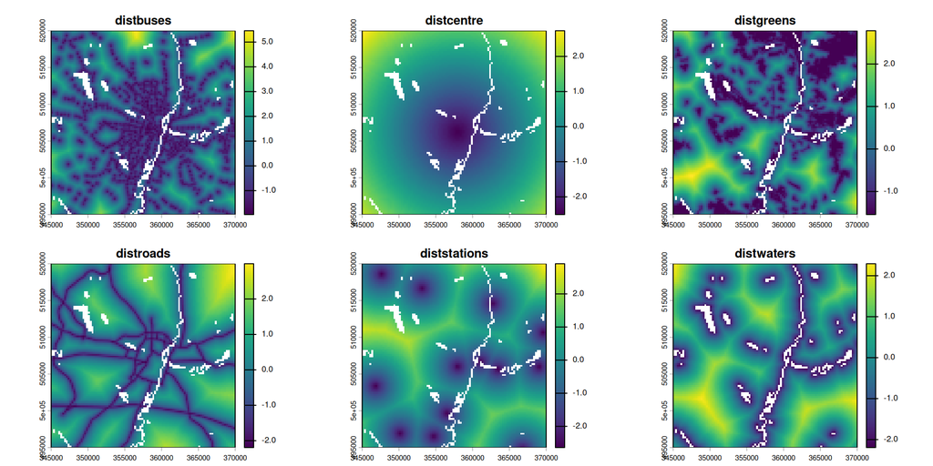

### Predykcja.

Utworzenie rastrów zawierających pierwsze trzy składowe dla całego terenu i zapisanie ich do pliku.

## Ocena.

### Przyporządkowanie wartości z PCA do punktów.

### Korelacja z ceną.

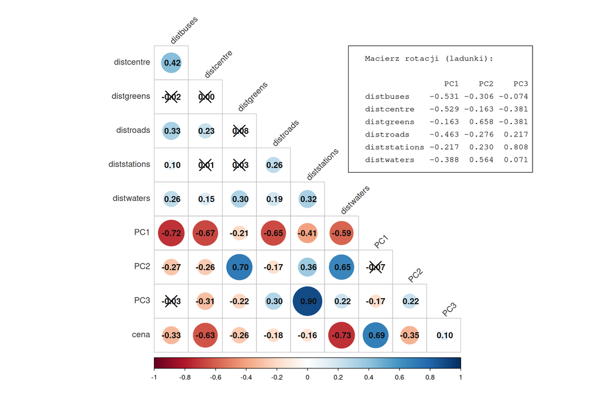

### Interpretacja.

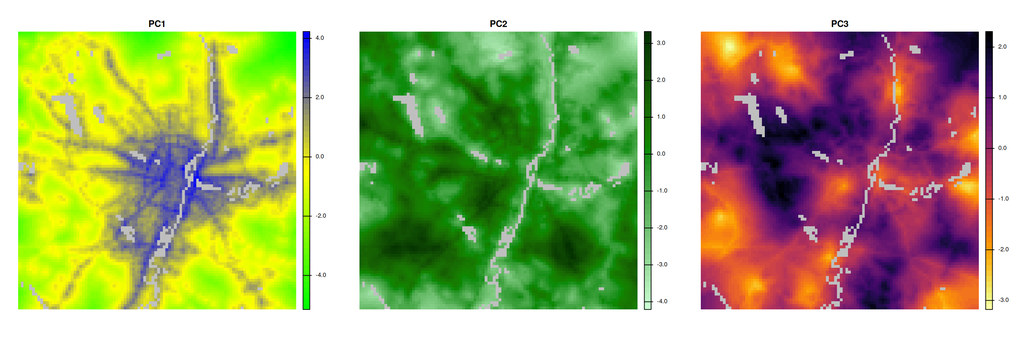

Pierwsza składowa jest ujemnie skorelowana z wszystkimi zmiennymi niezależnymi, najmocniej z odległością od przystanków autobusowych, centrum i głównych dróg. Wysokie wartości przyjmuje na terenach centrum, przy przystankach autobusowych i drogach. Niskie na niezabudowanych obrzeżach. Stąd jest wskaźnikiem oddalania się od terenów miejskich.

Trzecia składowa jest mocno dodatnio skorelowana ze zmienną odległości od stacji kolejowych, inne zmienne nie wpływają na nią znacząco. Stąd praktycznie jest tożsama ze zmienną odległości od stacji kolejowych, podniesionej do rangi głównej składowej. Jest tak, ponieważ odległość od stacji kolejowych dostatecznie mocno różni się od innych zmiennych i ma dość słaby związek ze zjawiskami opisywanymi przez pierwsze dwie składowe.

# Regresja liniowa

## Obliczenia.

### Podział na zbiór treningowy i testowy.

Dzielę zbiór punktów na zbiór treningowy i testowy w proporcjach 70 - 30. Część modeli będzie uczona na punktach z transformowanymi i skalowanymi wcześniej cechami, a inne na punktach z cechami, z których tylko usunięto wartości odstające.

### Modele regresji.

Jako najprostszy model do porównania przyjmuję równanie tylko na podstawie odległości od centrum. Następnie dwa modele regresji używające odległości od centrum, wód i terenów zielonych, w wersji trenowanej na danych z transformacją zmiennych i bez. Czwarty model regresji liniowej używa trzech pierwszych składowych PCA. Piąty używa wszytkich transformowanych zmiennych. Do najprostszego modelu używam funkcji `lm`, a do pozostałych pakietu `caret`.

## Wyniki.

### Równania i statystyki.

[output not shown]

Podczas treningu używane są jeszcze nieodtransformowane ceny, stąd inne rzędy wiekości RMSE na zbiorze treningowym dla modeli 3 i 4. Do porównania wyników na zbiorze testowym, dla modeli 3 i 4 odwróciłem skalowanie i transformcję, uzyskując oryginalne jednostki [PLN/m2].

Dla najprostszego modelu RMSE wynosi ponad 1100 PLN/m2. Używanie trzech pierwszych składowych obniża go o ok. 150. Jednak modele używające wybranych trzech zmiennych mają znacznie lepsze wyniki, o RMSE ok. 680 PLN/m2. Znaczy to, że składowe PCA nie są w tym wypadku efektywne do regresji liniowej. Model uczony na transformowanych danych osiąga minimalnie lepsze wyniki. Dodanie pozostałych zmiennych niezależnych poprawia RMSE nieznacznie, tylko do 642 PLN/m2.

### Ważność zmiennych.

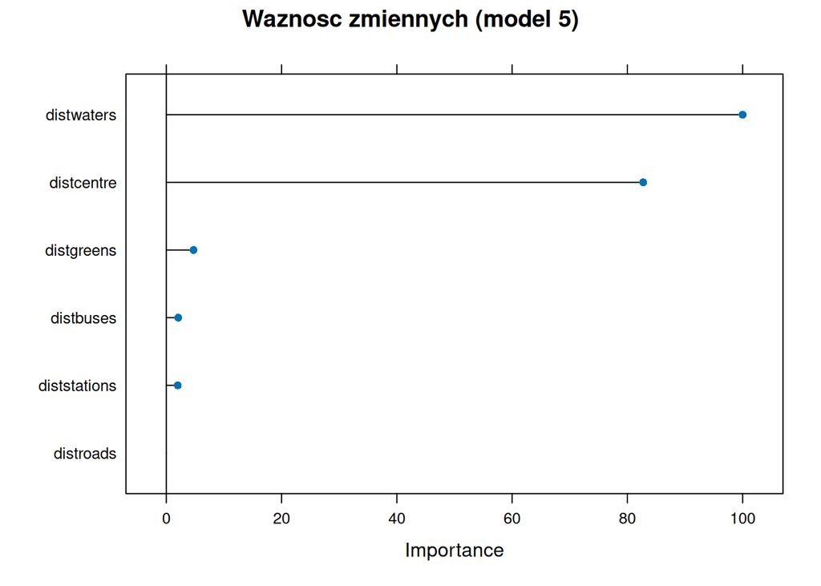

Najbardziej pomocne do predykcji ceny transakcji przez regresję liniową okazały się zmienne odległości od centrum, wód i terenów zielonych. Odległość od wody i centrum były wśród zmiennych najmocniej skorelowanych z ceną. Odległość od przystanków autobusowych również była skorelowana z ceną, ale najwyraźniej nie niosła dużo nowej informacji, ze względu na skorelowanie z poprzednimi dwiema zmiennymi niezależnymi. Bardziej pomocna okazała się odległość od terenów zielonych, mająca bardziej oryginalny charakter.

### Wizualizacja najprostszego modelu.

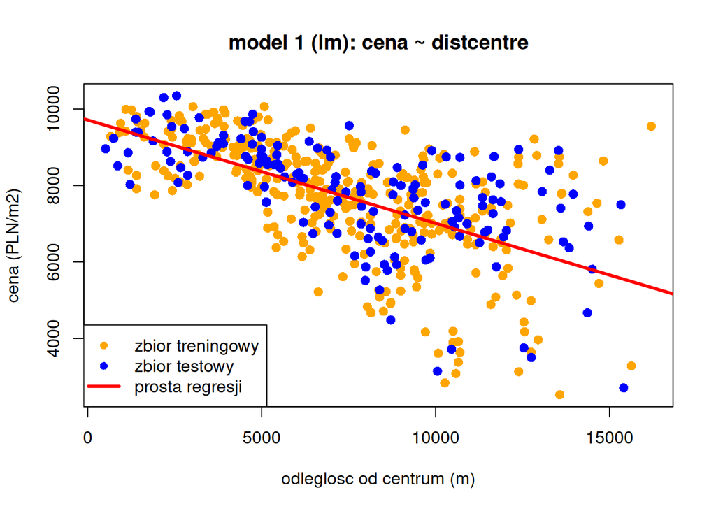

Model używający jednej zmiennej jest na tyle prosty, że można pokazać jego dopasowanie do punktów treningowych i testowych na jednym wykresie z oryginalnymi jednostkami.

### Testy normalności rozkładu reszt.

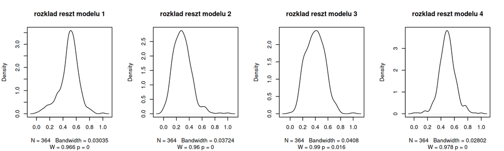

Rozkłady reszt modeli nieco zbliżają się do rozkładu normalnego (*W* - wynik testu Shapiro-Wilka), ale są wyraźnie różne (widoczne również na wykresie Q-Q w następnej sekcji). Jako że wartości odstające zostały wcześniej wyeliminowane, a skośność rozkładów zredukowana, z dużą pewnością stwierdzam, że modelowana zależność nie jest liniowa.

### Wykresy statystyk modeli.

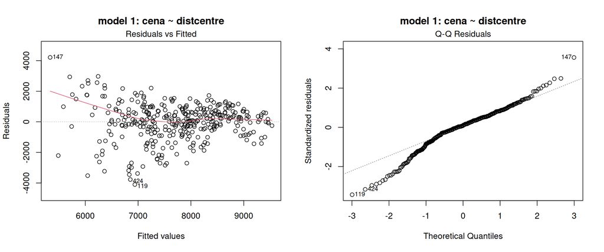

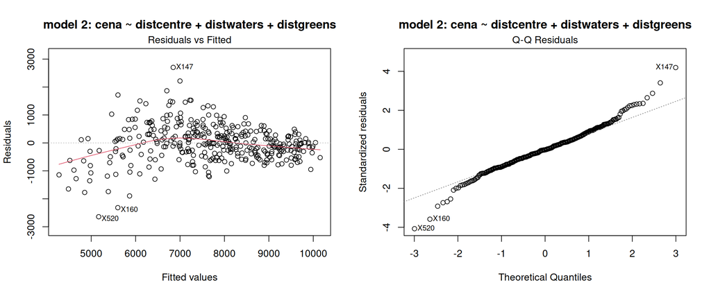

Widoczne lekkie wygięcie chmur reszt (residuals), co sugeruje nieliniowość relacji. Na wykresie najprostszego modelu widoczna heteroscedastyczność - wariancja reszt jest większa przy niższej przewidywanej cenie (fitted values). Może to oznaczać, że odległość od centrum bardziej pomaga przewidywać ceny drogich niż tanich nieruchomości. W zbiorze większość najdroższych nieruchomości była w centrum, a tańsze były bardzeij rozsiane po mapie.

# Alternatywne modelowanie.

Alternatywne testowane modele przewidujące ceny transakcji uczyłem na zbiorze bez transformacji, używając wszystkich zmiennych z wyjątkiem `distpublic`.

## Drzewo regresyjne.

### Obliczenia.

```r
model.drzewo.duze <- rpart(
  cena ~ distcentre + distwaters + distgreens + distbuses + distroads + diststations,
  data = trening.bez.trans.skal,
  method = "anova",
  control = rpart.control(cp = 0.0001)
)
testy.drzewo <- predict(model.drzewo.duze, newdata = test.bez.trans.skal.bez.ceny)
staty.drzewo <- postResample(pred = testy.drzewo, obs = test.cena.oryginalna$cena)
```

### Wielkość.

```
       CP nsplit rel error    xerror       xstd
29 0.0001     29 0.1198643 0.2565687 0.03239968
```

### Grafika.

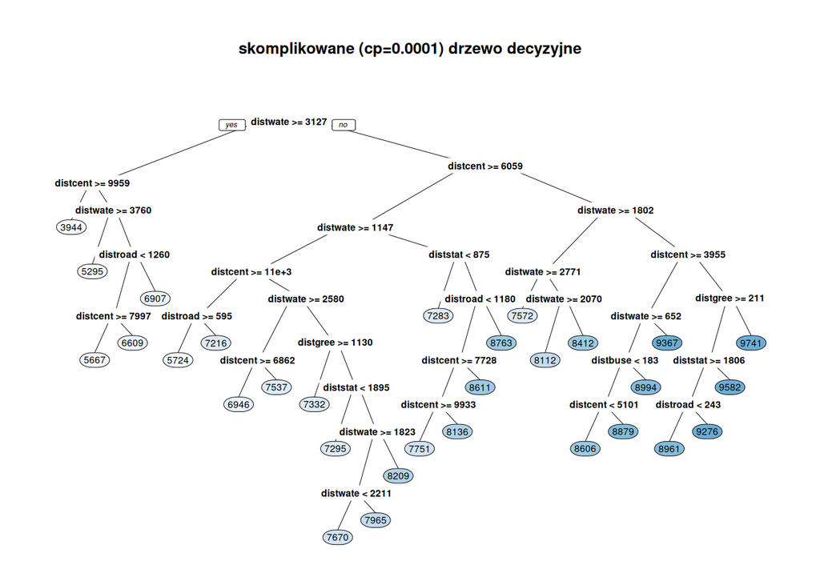

## Las losowy.

### Obliczenia.

```r
model.las.maly <- train(
  cena ~ distcentre + distwaters + distgreens + distbuses + distroads + diststations,
  data = trening.bez.trans.skal,
  method = "ranger",
  tuneGrid = expand.grid(mtry = c(2,3,4,5), splitrule = c("variance"), min.node.size = c(2,5)),
  num.trees = 10,
  max.depth = 5,
  trControl = kontrola
)
testy.las <- predict(model.las.maly, newdata = test.bez.trans.skal.bez.ceny)
staty.las <- postResample(pred = testy.las, obs = test.cena.oryginalna$cena)
```

### Wielkość.

```
[1] "Łączna liczba podziałów we wszystkich 10 drzewach wynosi: 257"
```

## Lokalnie ważona regresja.

### Obliczenia.

```r
model.cubist.maly <- train(
  cena ~ distcentre + distwaters + distgreens + distbuses + distroads + diststations,
  data = trening.bez.trans.skal,
  method = "cubist",
  tuneGrid = expand.grid(committees = c(1,2), neighbors = c(0,1)),
  trControl = kontrola
)
testy.cubist <- predict(model.cubist.maly, newdata = test.bez.trans.skal.bez.ceny)
staty.cubist <- postResample(pred = testy.cubist, obs = test.cena.oryginalna$cena)
```

### Wzory i wielkość.

```
Call:
cubist.default(x = x, y = y, committees = param$committees)


Cubist [Release 2.07 GPL Edition]
---------------------------------

    Target attribute `outcome'

Read 364 cases (7 attributes) from undefined.data

Model 1:

  Rule 1/1: [58 cases, mean 5419.157, range 2525.82 to 7599.73, est err 459.206]

    if
    distwaters > 3127.046
    then
    outcome = 13403.004 - 0.512 distcentre - 1.1 distwaters + 0.62 distroads
              + 0.12 distgreens

  Rule 1/2: [37 cases, mean 7008.898, range 3282.2 to 9215.64, est err 820.081]

    if
    distcentre > 10347.38
    distwaters <= 3127.046
    distroads <= 875.3745
    then
    outcome = 9377.784 - 2.76 distroads - 1.14 distwaters + 1.23 distbuses
              - 0.08 distgreens + 0.022 diststations

  Rule 1/3: [17 cases, mean 7454.426, range 5136.94 to 9548.14, est err 452.100]

    if
    distcentre > 10347.38
    distwaters <= 3127.046
    distroads > 875.3745
    then
    outcome = 8373.936 - 1.31 distwaters + 0.38 distroads - 0.13 distgreens
              + 0.035 diststations
```

[output cut: 19 more lines]

```

    Average  |error|            425.707
    Relative |error|               0.37
    Correlation coefficient        0.92


    Attribute usage:
      Conds  Model

       50%   100%    distwaters
       42%    93%    distcentre
        7%   100%    distroads
              57%    diststations
              50%    distgreens
               5%    distbuses
```

### Ważność zmiennych.

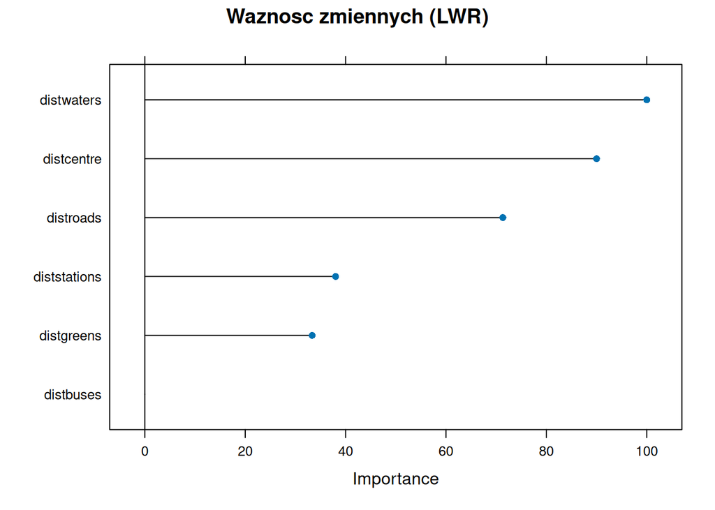

## Wyniki.

### Wielkości i wyniki.

[output not shown]

Pojedyncze drzewo regresyjne osiąga gorsze wyniki niż standardowa regresja liniowa. Las losowy ma porównywalny RMSE z regresją liniową, ale jest znacznie bardziej złożony. Lokalnie ważona regresja osiąga najniższy RMSE, na poziomie 580 PLN/m2.

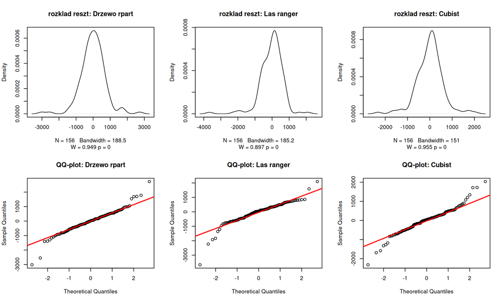

Mniej wartości odstaje od linii prostej na wykresach Q-Q alternatywnych modeli.

# Mapy predykcji.

Trzeba wziąć pod uwagę, że odwracanie transformacji ceny dla predykcji, w której występują wartości spoza widzianych wcześniej przez transformację przedziałów, daje wartości nieokreślone. Dlatego należy przyciąć predykcje modeli uczonych na transformowanych danych do odpowiedniego przedziału.

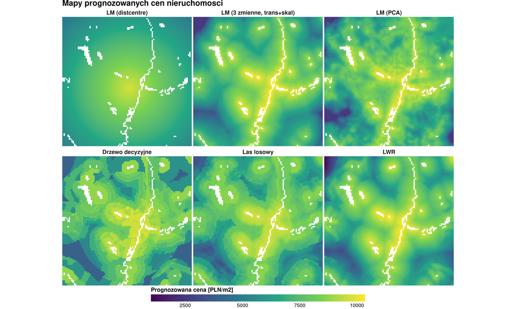

# Klasteryzacja

## Obliczenia.

### Funkcja pomocnicza.

### Dane do klasteryzacji.

### Wybrane.

### PCA.

## Mapy porównawcze dla kmeans.

### Funkcja pomocnicza.

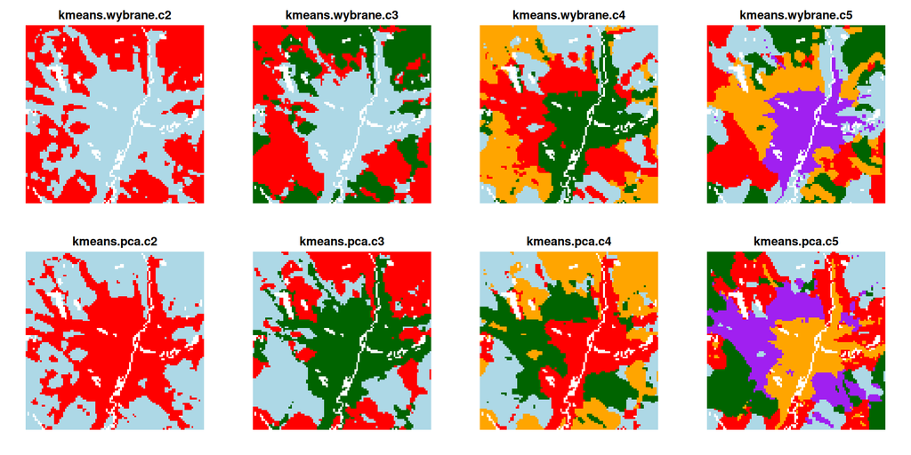

Wybieram liczbę czterech klastrów jako najlepszą, a trzech do porównania.